# Normal Distribution

Shih-Ni Prim

2026-08-30

# IM construction

This page shows a toy example of how to construct a possibilistic inferential model (IM) when the data is assumed to come from a Normal distribution with mean $\theta$ and variance $1$.

## Relative likelihood

To construct an inferential model, we first construct the relative likelihood:
$$R(x, \theta) =
\frac{p_{\theta}(x)}{\sup_{\vartheta} p_\vartheta(x)},$$
where $p_{\theta}(x)$ is the likelihood function with parameter $\theta$ and observed data $x$.

Assuming we observe $x \in X$ and $X \sim N(\theta, 1)$, the maximum likelihood estimator is $\widehat{\theta}=x$.

$$\begin{align}
R(x,\theta) &= \frac{p_{\theta}(x)}{p_{\widehat{\theta}}(x)} =
p_{\theta}(x) = p(|x-\theta|),
\end{align}$$
where $p$ is the density function for standard Normal distribution.

## Contour function

The next step is a validation step:

$$\pi_x(\theta) = P_\theta(R(X, \theta)
\le R(x, \theta)).$$

For the Normal distribution, there is a closed form for the contour.

$$\begin{align}
\pi_x(\theta) &= P_\theta \{ p(X-\theta) \le p(x-\theta) \} \\
&= P_\theta \{ |X-\theta| \le |x-\theta|\} \\
&= 2 \{1 - P(|x-\theta|) \},
\end{align}$$
where $P$ is the cumulative distribution function for standard Normal distribution. The above derivation works for sample size $n=1$. When $n>1$, the sample mean ($\bar{x}$) and the sample variance ($1/\sqrt{n}$) are used instead.

$$\pi_x(\theta) = 2 \{ 1 - P(\sqrt{n}
\cdot |\bar{x} - \theta| ) \}.$$

The code below finds the contour function $\pi_x(\theta)$ given observation $x$ and the parameter of interest $\theta$.

```r
contour_normal <- function(x, theta){
  x_bar <- mean(x)
  n <- length(x)
  return(2 * (pnorm(abs(x_bar-theta)*sqrt(n), lower.tail = F) ))
}
```

## Example demonstration

Now we assume the true parameter is $0$ and sample size is $1$, let’s plot the contour function given that we observed $x=1$.

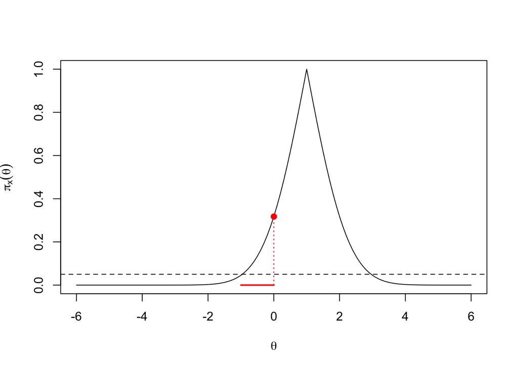

```r
n <- 1
true_theta <- 0
X <- 1

theta <- seq(true_theta-6, true_theta+6, .1)
pi_normal <- contour_normal(X, theta)
plot(theta, pi_normal, type = "l", xlab = expression(theta), ylab = expression(pi[x](theta)))
pi_true_theta <- contour_normal(X, true_theta)
abline(h=.05, lty=2)
segments(-1, 0, 0, 0, col="red", lwd=2)
segments(0, 0, 0, contour_normal(X,0), lty=3, col="red")
points(0, contour_normal(X,0), col="red", pch=19)
```

As shown above, the black curve is the contour function for $x=1$. The possibility measure (or upper probability) of the hypothesis $h=[-1,0]$ can be found by maximization:

$$\Pi_x(h) = \sup_{\theta \in [-1,0]}
\pi_x(\theta) \approx 0.317,$$
where the red circle is.

To find a $95\%$ confidence set, the black dashed line at $0.05$ shows that the set is approximately $[-1, 3]$.

# Reference

Martin, Ryan. (2026). Possibilistic inferential models: a review. *Journal of American Statistical Association,* 121 (553): 807-826. [Preprint](https://arxiv.org/abs/2507.09007).